# Hands-on: Clustering, PCA & MCA untuk Data Asuransi

Latihan analisis di R dengan data polis asuransi kendaraan `dataCar` (paket insuranceData)

# Part 0 · Persiapan

Tujuan latihan ini adalah mempraktikkan **PCA, MCA, dan berbagai metode clustering** pada data asuransi kendaraan, lalu menafsirkan hasilnya dari sudut pandang bisnis asuransi.

## Cara membaca kode di modul ini

Setiap blok kode diberi label supaya Anda tahu mana yang harus dikuasai dan mana yang cukup dipahami:

| Label | Artinya | Yang perlu Anda lakukan |
| --- | --- | --- |
| **WAJIB** | Langkah inti analisis: menyiapkan data, menjalankan metode, dan membaca hasil utama. Tanpa kode ini analisis tidak jalan. | Pahami tiap baris dan **hafalkan polanya** (nama fungsi + argumen penting). |
| **PELENGKAP** | Grafik dan pengecekan hasil (`fviz_*`, `plot`, `summary`, tabel silang). Membantu membaca hasil, tetapi analisis tetap jalan tanpanya. | Cukup tahu **fungsi apa untuk grafik apa**; argumen tampilan (warna, label, ukuran) tidak perlu dihafal. |
| **OPSIONAL** | Pembanding atau pendalaman (metode alternatif, latihan tambahan). | Boleh dilewati jika waktu terbatas. |

Setiap baris kode juga diberi komentar `# ...` yang menjelaskan maksudnya. Di akhir modul ada **Contekan kode wajib** yang merangkum semua kode WAJIB dalam satu tempat untuk dihafal.

Di R, tanda `<-` berarti “simpan hasil ke dalam objek”. Contoh: `km <- kmeans(...)` artinya “jalankan k-means, simpan hasilnya dengan nama `km`”. Tanda `$` dipakai untuk mengambil bagian dari objek, misalnya `km$cluster` = nomor cluster tiap baris data.

## Package yang dipakai

Jalankan sekali saja jika package belum terpasang:

```r
# Memasang package dari CRAN. Cukup SEKALI per komputer, tidak perlu diulang tiap sesi.
install.packages(c("insuranceData",   # berisi data dataCar
                   "cluster",         # pam(), daisy(), silhouette
                   "factoextra",      # grafik PCA, MCA, dan cluster (fungsi fviz_*)
                   "FactoMineR",      # MCA()
                   "dbscan",          # dbscan()
                   "clustMixType", "klaR"))   # dua terakhir hanya untuk bagian opsional
```

```r
# Memuat package ke sesi R. WAJIB dijalankan setiap kali R dibuka ulang.
library(cluster)      # pam(), daisy(), silhouette()
library(factoextra)   # visualisasi PCA, MCA, cluster
library(FactoMineR)   # MCA()
library(dbscan)       # dbscan(), kNNdistplot()
```

## Data latihan: `dataCar`

Data `dataCar` dari package **insuranceData** berisi **67.856 polis asuransi kendaraan** satu tahun (periode 2004–2005, Australia), 4.624 di antaranya mengajukan klaim.

| Variabel | Arti | Jenis |
| --- | --- | --- |
| `veh_value` | Nilai kendaraan, dalam satuan 10.000 AUD | numerik |
| `exposure` | Lama polis aktif dalam setahun (0–1) | numerik |
| `clm` | Ada klaim? (1 = ya, 0 = tidak) | biner |
| `numclaims` | Jumlah klaim dalam periode polis | numerik (0–4) |
| `claimcst0` | Total biaya klaim (AUD; 0 jika tidak klaim) | numerik |
| `veh_body` | Jenis bodi kendaraan (SEDAN, HBACK = hatchback, STNWG = station wagon, UTE = pikap, dll.) | kategorik |
| `veh_age` | Kelompok umur kendaraan: 1 = paling baru … 4 = paling tua | ordinal |
| `gender` | Jenis kelamin pengemudi (F/M) | kategorik |
| `area` | Wilayah tempat tinggal (A–F) | kategorik |
| `agecat` | Kelompok usia pengemudi: 1 = paling muda … 6 = paling tua | ordinal |
| `X_OBSTAT_` | Kolom teknis, isinya sama semua, tidak dipakai | – |

Pembagian pemakaian data:

| Bagian | Data yang dipakai | Metode |
| --- | --- | --- |
| Part 1–3 | 4.624 polis yang **mengajukan klaim** (variabel numerik) | PCA, k-means, PAM, hierarchical, DBSCAN |
| Part 4–5 | **Sampel 2.000 polis** (semua polis, klaim maupun tidak) | MCA, clustering data campuran |

```r
data("dataCar", package = "insuranceData")   # memuat data dataCar ke memori R
dim(dataCar)                                   # jumlah baris (polis) dan kolom (variabel)
```

```
#> [1] 67856    11
```

# Part 1 · Eksplorasi Data Klaim

Sebelum PCA atau clustering, pahami dulu bentuk datanya. Biaya klaim hampir selalu **miring ke kanan** (*heavy-tailed*): banyak klaim kecil dan sedikit klaim sangat besar.

## Memilih polis yang klaim

```r
klaim <- subset(dataCar, clm == 1)   # ambil hanya baris dengan clm = 1 (polis yang klaim)
nrow(klaim)                          # berapa banyak polis yang klaim
```

```
#> [1] 4624
```

```r
# ringkasan statistik (min, kuartil, median, rata-rata, maks) variabel yang akan dipakai
summary(klaim[, c("veh_value", "veh_age", "claimcst0", "numclaims")])
```

```
#>    veh_value         veh_age        claimcst0         numclaims
#>  Min.   : 0.000   Min.   :1.000   Min.   :  200.0   Min.   :1.000
#>  1st Qu.: 1.100   1st Qu.:2.000   1st Qu.:  353.8   1st Qu.:1.000
#>  Median : 1.570   Median :3.000   Median :  761.6   Median :1.000
#>  Mean   : 1.859   Mean   :2.626   Mean   : 2014.4   Mean   :1.068
#>  3rd Qu.: 2.310   3rd Qu.:4.000   3rd Qu.: 2091.4   3rd Qu.:1.000
#>  Max.   :13.900   Max.   :4.000   Max.   :55922.1   Max.   :4.000
```

```r
table(klaim$numclaims)   # hitung berapa polis yang klaim 1x, 2x, 3x, 4x
```

```
#>
#>    1    2    3    4
#> 4333  271   18    2
```

- Median biaya klaim hanya **762 AUD**, tetapi maksimumnya **55922 AUD**, dan rata-ratanya (2014) jauh di atas median: distribusinya sangat miring.
- Sebagian besar polis hanya klaim sekali; hanya 291 polis (6%) yang klaim 2 kali atau lebih.

## Transformasi log dan standardisasi

Jarak Euclid (dipakai PCA dan k-means) sangat sensitif terhadap nilai ekstrem. Karena itu variabel yang miring kita transformasi log dulu, lalu semua variabel **distandardisasi** (mean 0, sd 1) supaya satuannya setara.

```r
# Susun data numerik untuk analisis. Nama kolom dibuat singkat supaya grafik mudah dibaca.
X <- data.frame(nilai  = log1p(klaim$veh_value),   # log(1 + nilai kendaraan); log1p aman untuk nilai 0
                umur   = klaim$veh_age,            # umur kendaraan 1-4 (tidak miring, tidak perlu log)
                biaya  = log(klaim$claimcst0),     # log biaya klaim (semua > 0, jadi cukup log)
                jumlah = klaim$numclaims)          # jumlah klaim 1-4

Z <- scale(X)    # standardisasi: setiap kolom dikurangi rata-rata lalu dibagi sd
```

- `log1p(x)` = `log(1 + x)`. Dipakai jika data bisa bernilai 0 (karena `log(0)` tidak terdefinisi).
- `scale()` menghasilkan **z-score**. Tanpa ini, variabel dengan angka besar akan mendominasi jarak.
- Hasil `X` dipakai untuk PCA (PCA melakukan standardisasi sendiri lewat `scale. = TRUE`); hasil `Z` dipakai untuk clustering.

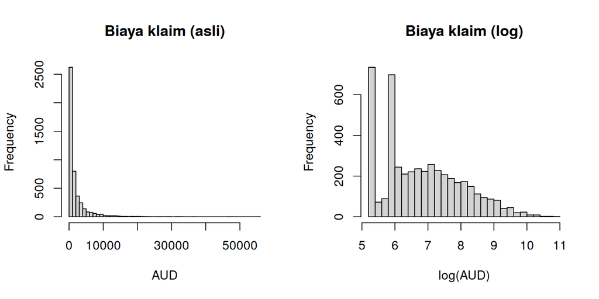

```r
par(mfrow = c(1, 2))                    # bagi area gambar menjadi 1 baris, 2 kolom
hist(klaim$claimcst0, breaks = 60,      # histogram biaya klaim asli
     main = "Biaya klaim (asli)", xlab = "AUD")
hist(log(klaim$claimcst0), breaks = 40, # histogram setelah di-log
     main = "Biaya klaim (log)", xlab = "log(AUD)")
```

```r
round(cor(X), 2)   # matriks korelasi antar variabel, dibulatkan 2 desimal
```

```
#>        nilai  umur biaya jumlah
#> nilai   1.00 -0.60 -0.02   0.00
#> umur   -0.60  1.00  0.06   0.00
#> biaya  -0.02  0.06  1.00   0.17
#> jumlah  0.00  0.00  0.17   1.00
```

- Korelasi terkuat adalah **nilai kendaraan vs umur kendaraan** (-0.6): mobil yang lebih tua cenderung bernilai lebih rendah.
- **Biaya** dan **jumlah klaim** berkorelasi positif lemah (0.17): polis yang klaim berkali-kali cenderung total biayanya lebih besar.
- Kedua pasangan ini hampir tidak berkorelasi satu sama lain. PCA akan menangkap pola ini sebagai dua sumbu terpisah.

# Part 2 · PCA pada Data Klaim

PCA meringkas beberapa variabel numerik yang saling berkorelasi menjadi **komponen baru (Dim)** yang tidak berkorelasi.

## Menjalankan PCA

```r
res.pca <- prcomp(X, scale. = TRUE)   # jalankan PCA; scale. = TRUE -> variabel distandardisasi dulu
eig <- get_eigenvalue(res.pca)        # ambil eigenvalue & persen varians tiap Dim (factoextra)
round(eig, 2)
```

|  | eigenvalue | variance.percent | cumulative.variance.percent |
| --- | --- | --- | --- |
| Dim.1 | 1.61 | 40.21 | 40.21 |
| Dim.2 | 1.17 | 29.15 | 69.36 |
| Dim.3 | 0.83 | 20.71 | 90.07 |
| Dim.4 | 0.40 | 9.93 | 100.00 |

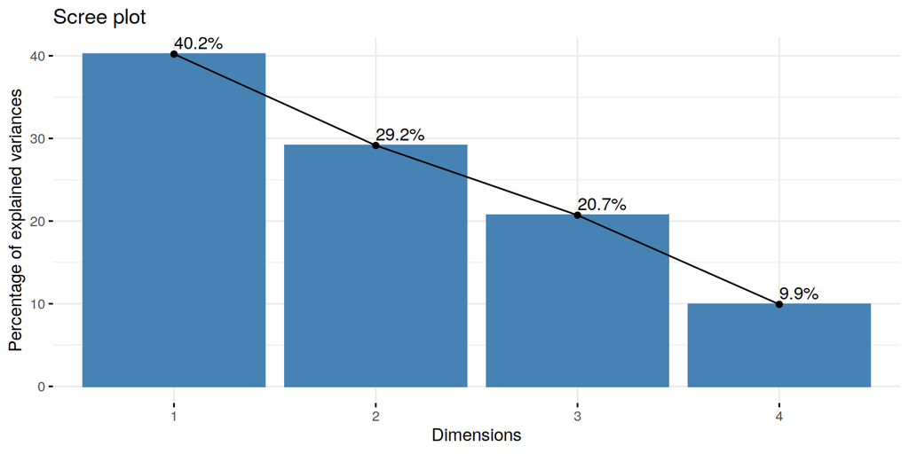

```r
fviz_eig(res.pca, addlabels = TRUE)   # scree plot: persen varians tiap Dim; addlabels = tulis angkanya
```

- **eigenvalue**: besar variasi yang ditangkap tiap Dim. Totalnya = jumlah variabel = 4.
- Dim 1 menjelaskan 40.2% variasi, Dim 1 + Dim 2 = 69.4%.
- **Aturan Kaiser** (eigenvalue ≥ 1) memilih **2 Dim** (1.61 dan 1.17). Kita pakai Dim 1 dan Dim 2.

## Loading dan lingkaran korelasi

```r
round(res.pca$rotation, 2)   # loading: bobot tiap variabel asli di setiap Dim (PC)
```

```
#>          PC1   PC2   PC3   PC4
#> nilai   0.70  0.09  0.07  0.70
#> umur   -0.70 -0.05 -0.01  0.71
#> biaya  -0.11  0.70  0.71 -0.05
#> jumlah -0.03  0.71 -0.70  0.01
```

Cara membaca loading: lihat angka dengan **nilai mutlak besar** (misalnya > 0.5) di tiap kolom. Tanda +/− menunjukkan arah. Contoh: di PC1 `nilai` bertanda + dan `umur` bertanda −, artinya PC1 tinggi = mobil bernilai tinggi dan masih baru.

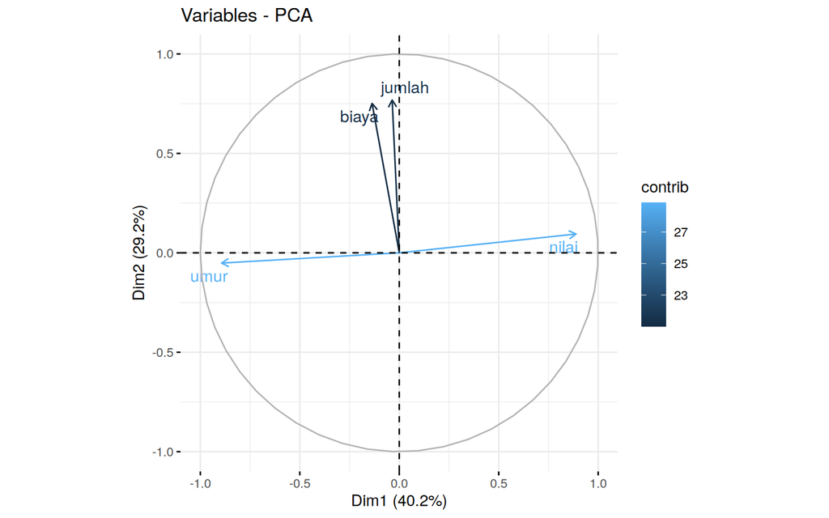

```r
# lingkaran korelasi; col.var = "contrib" -> warna panah sesuai kontribusi; repel -> label tidak bertumpuk
fviz_pca_var(res.pca, col.var = "contrib", repel = TRUE)
```

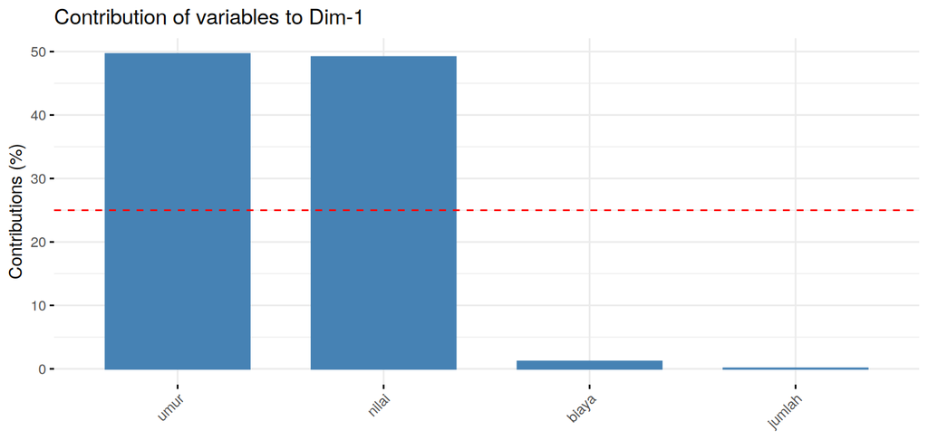

```r
fviz_contrib(res.pca, choice = "var", axes = 1)   # kontribusi variabel ke Dim 1
```

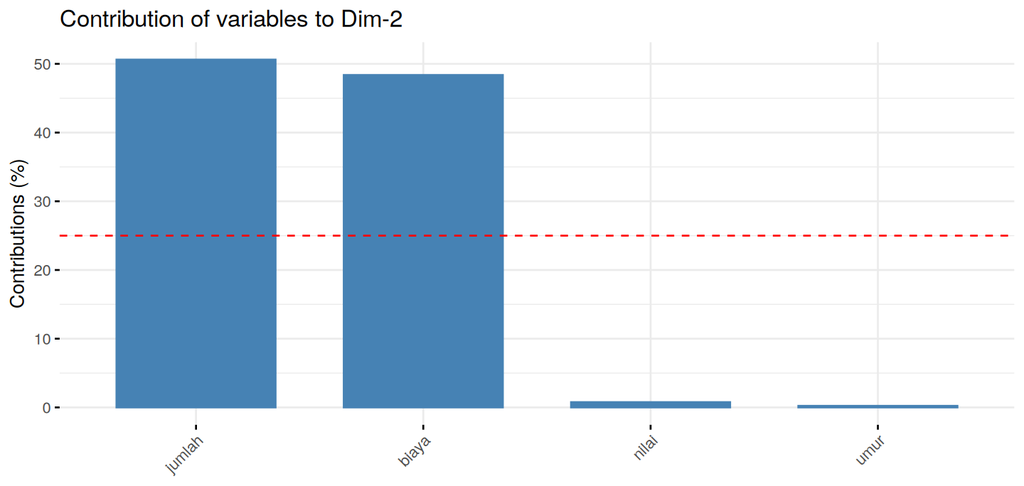

```r
fviz_contrib(res.pca, choice = "var", axes = 2)   # kontribusi variabel ke Dim 2
```

- **Dim 1 = “profil kendaraan”**: `nilai` (+) dan `umur` (−) berlawanan arah. Nilai Dim 1 tinggi = kendaraan **baru dan mahal**; rendah = kendaraan **tua dan murah**.
- **Dim 2 = “keparahan klaim”**: dibentuk oleh `biaya` dan `jumlah`. Nilai Dim 2 tinggi = polis dengan **klaim mahal dan/atau berulang**.
- Panah yang panjang dan dekat lingkaran berarti variabel itu terwakili baik di bidang Dim 1–Dim 2 (cos2 tinggi).
- Garis merah putus-putus pada plot kontribusi = kontribusi rata-rata (100% / 4 = 25%); variabel di atas garis adalah pembentuk utama Dim tersebut.

## Plot individu (polis yang klaim)

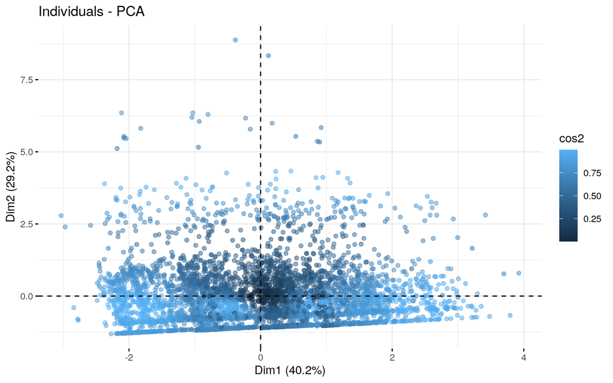

```r
fviz_pca_ind(res.pca, geom = "point",      # setiap titik = satu polis; geom = "point" -> tanpa label
             col.ind = "cos2", alpha.ind = 0.5)   # warna = kualitas representasi (cos2)
```

Klaim di kanan adalah polis dengan kendaraan baru/mahal; klaim di atas adalah polis dengan klaim besar atau berulang. “Garis-garis” titik yang terlihat muncul karena `umur` dan `jumlah` hanya bernilai bulat 1–4 (variabel diskrit).

Ulangi PCA dengan menambahkan `exposure` dan `agecat` ke dalam `X`. Apa yang terjadi pada persen varians Dim 1 dan Dim 2? Apakah variabel baru itu berkorelasi dengan variabel lain? (Petunjuk: lihat `cor(X)` dulu.)

# Part 3 · Clustering Polis yang Klaim

Tujuan bisnis: mengelompokkan klaim menjadi segmen dengan pola berbeda, misalnya untuk penetapan cadangan, penanganan klaim, atau deteksi klaim tidak lazim.

## Menentukan jumlah cluster (k)

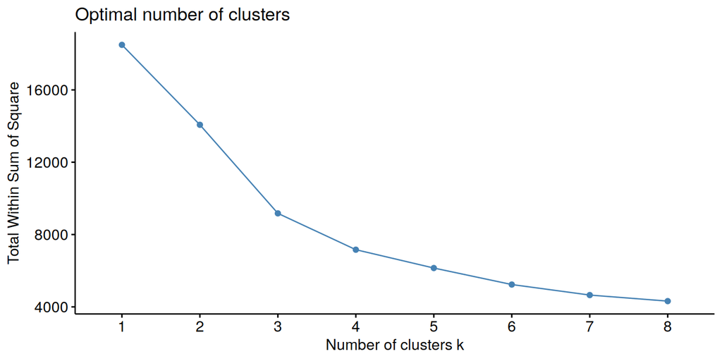

```r
set.seed(123)                                               # kunci angka acak agar hasil bisa diulang
fviz_nbclust(Z, kmeans, method = "wss", k.max = 8)          # elbow: total jarak dalam cluster per k
```

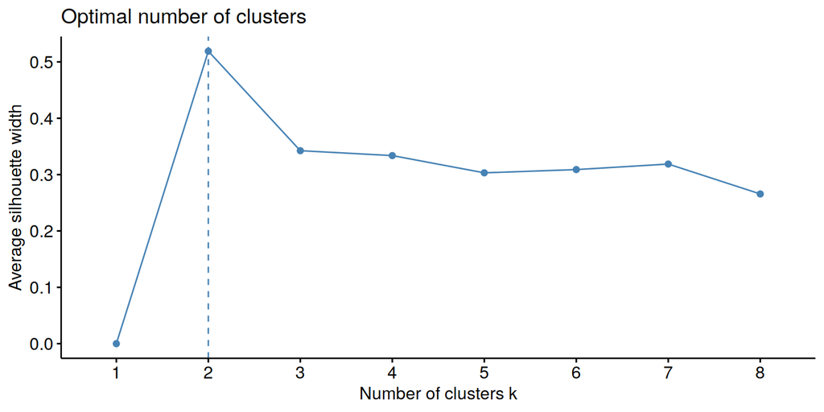

```r
fviz_nbclust(Z, kmeans, method = "silhouette", k.max = 8)   # rata-rata silhouette per k
```

- `method = "wss"` (*within sum of squares*): cari **siku**, titik ketika penurunan garis mulai melandai.
- `method = "silhouette"`: cari **nilai tertinggi**. Silhouette berkisar −1 s.d. 1; makin tinggi, makin jelas pemisahan cluster.

## K-Means

```r
set.seed(123)                                  # k-means memakai titik awal acak
km <- kmeans(Z, centers = 4, nstart = 25)      # 4 cluster, coba 25 titik awal, ambil yang terbaik
table(km$cluster)                              # jumlah polis per cluster
```

```
#>
#>    1    2    3    4
#>  291 1107 1817 1409
```

- `centers` = jumlah cluster (k).
- `nstart = 25`: k-means diulang 25 kali dengan titik awal berbeda, lalu dipilih hasil terbaik. Ini membuat hasil lebih stabil.
- `km$cluster` = nomor cluster setiap polis; `km$centers` = pusat cluster (dalam skala z).

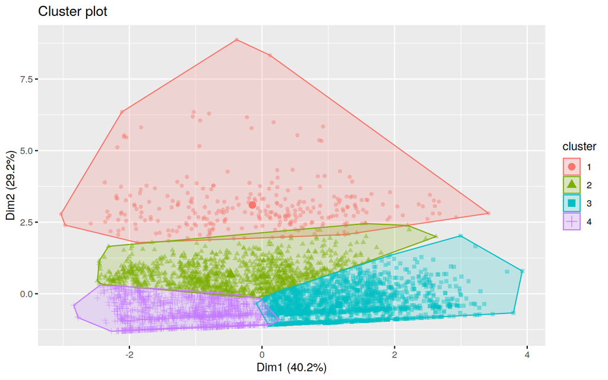

```r
fviz_cluster(km, data = Z, geom = "point",      # gambar cluster di bidang Dim 1-Dim 2 (PCA otomatis)
             ellipse.type = "convex", alpha = 0.4)
```

## Profil cluster

Profil selalu dibaca dari **data asli**, bukan data yang sudah di-log atau di-scale.

```r
# median tiap variabel asli per cluster
prof <- aggregate(klaim[, c("veh_value", "veh_age", "claimcst0", "numclaims")],
                  by = list(cluster = km$cluster), FUN = median)
prof$rata_biaya <- as.vector(tapply(klaim$claimcst0, km$cluster, mean))   # rata-rata biaya per cluster
prof$n <- as.vector(table(km$cluster))                                    # jumlah polis per cluster
knitr::kable(prof, digits = 2, caption = "Median per cluster (biaya dalam AUD)")   # tampilkan tabel rapi
```

Median per cluster (biaya dalam AUD)

| cluster | veh_value | veh_age | claimcst0 | numclaims | rata_biaya | n |
| --- | --- | --- | --- | --- | --- | --- |
| 1 | 1.63 | 3 | 1804.99 | 2 | 3021.95 | 291 |
| 2 | 1.41 | 3 | 3771.08 | 1 | 5567.67 | 1107 |
| 3 | 2.34 | 2 | 443.84 | 1 | 782.93 | 1817 |
| 4 | 1.04 | 4 | 390.00 | 1 | 602.71 | 1409 |

- `aggregate(data, by = list(cluster = ...), FUN = median)`: hitung median setiap kolom untuk setiap cluster.
- `tapply(x, kelompok, mean)`: hitung rata-rata `x` untuk setiap kelompok.
- `knitr::kable()` hanya untuk mempercantik tampilan tabel (boleh diganti `print(prof)`).
- **Cluster 3 – kendaraan baru/mahal, klaim kecil** (1817 polis): median nilai kendaraan 2.34 (×10.000 AUD), umur kelompok 2, median biaya klaim 444 AUD.
- **Cluster 4 – kendaraan tua/murah, klaim kecil** (1409 polis): median nilai 1.04, umur kelompok 4, median biaya 390 AUD.
- **Cluster 2 – klaim besar** (1107 polis): median biaya **3771 AUD**, sekitar 10× lipat klaim kecil. Segmen ini paling relevan untuk cadangan klaim.
- **Cluster 1 – klaim berulang** (291 polis): semua polis di sini klaim **2 kali atau lebih**; rata-rata total biayanya 3022 AUD. Segmen ini relevan untuk evaluasi underwriting dan premi perpanjangan.

## K-Medoids (PAM)

PAM memakai **titik data nyata (medoid)** sebagai pusat cluster, sehingga lebih tahan terhadap outlier daripada k-means.

```r
pm <- pam(Z, k = 4)                  # PAM dengan 4 cluster (tidak perlu set.seed, hasilnya tetap)
klaim[pm$id.med, c("veh_value", "veh_age", "claimcst0", "numclaims")]   # polis "wakil" tiap cluster
```

|  | veh_value | veh_age | claimcst0 | numclaims |
| --- | --- | --- | --- | --- |
| 31085 | 2.27 | 2 | 515.97 | 1 |
| 40250 | 1.36 | 3 | 3413.85 | 1 |
| 40478 | 0.95 | 4 | 415.65 | 1 |
| 20562 | 1.52 | 3 | 2010.08 | 2 |

`pm$id.med` = nomor baris medoid. Karena medoid adalah polis nyata, kita bisa langsung melihat data aslinya: ini “polis tipikal” dari setiap cluster.

```r
table(KMeans = km$cluster, PAM = pm$clustering)   # tabel silang: seberapa sama hasil k-means dan PAM
```

```
#>       PAM
#> KMeans    1    2    3    4
#>      1    0    0    0  291
#>      2   37 1070    0    0
#>      3 1817    0    0    0
#>      4  113  126 1170    0
```

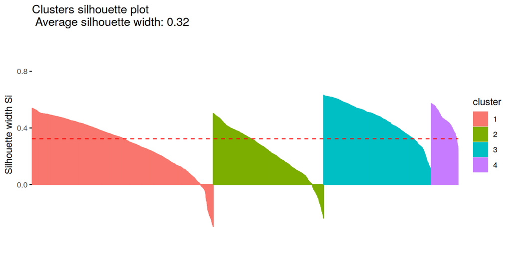

```r
fviz_silhouette(pm, print.summary = FALSE)   # plot silhouette tiap polis
```

Tabel silang menunjukkan seberapa konsisten PAM dengan k-means (nomor cluster boleh berbeda; yang dilihat adalah apakah anggota berkumpul di satu sel per baris). Pada plot silhouette, batang yang panjang (mendekati 1) berarti polis itu cocok di cluster-nya; batang negatif berarti polis itu mungkin lebih cocok di cluster lain. Rata-rata silhouette PAM = 0.32.

## Hierarchical clustering

```r
hc <- hclust(dist(Z), method = "ward.D2")   # dist() = matriks jarak Euclid; ward.D2 = metode penggabungan
grup_hc <- cutree(hc, k = 4)                # potong dendrogram menjadi 4 cluster
```

- `dist(Z)` menghitung jarak antar **semua pasangan** polis (4.624 × 4.624). Untuk data sangat besar, ini berat; ambil sampel dulu.
- `method = "ward.D2"` menggabungkan cluster yang paling sedikit menambah variasi dalam cluster; biasanya menghasilkan cluster yang seimbang.
- `cutree()` mengubah dendrogram menjadi nomor cluster.

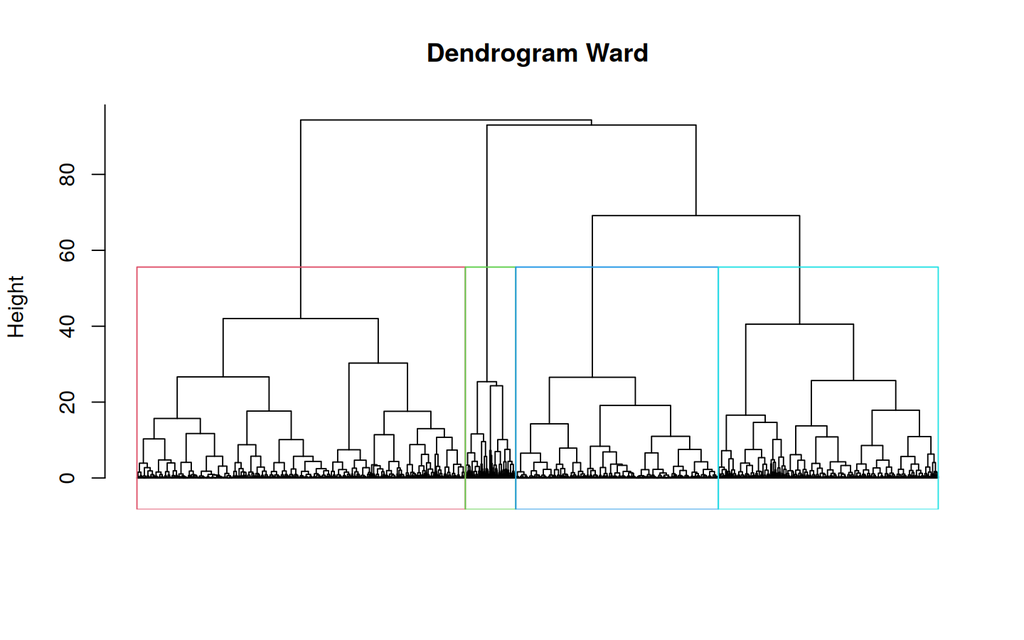

```r
plot(hc, labels = FALSE, hang = -1, main = "Dendrogram Ward", xlab = "", sub = "")   # gambar dendrogram
rect.hclust(hc, k = 4, border = 2:5)                                               # kotak 4 cluster
```

```r
table(Hierarki = grup_hc, KMeans = km$cluster)   # bandingkan dengan k-means
```

```
#>         KMeans
#> Hierarki    1    2    3    4
#>        1    0    0    0 1169
#>        2  291    0    0    0
#>        3    0   75 1780   40
#>        4    0 1032   37  200
```

Tinggi sambungan menunjukkan seberapa berbeda dua kelompok yang digabung. Potongan di 4 cluster dipilih di bagian dengan “loncatan” tinggi yang besar. Tabel silang memperlihatkan bahwa segmen klaim berulang dan klaim kendaraan baru ditemukan oleh kedua metode; perbedaan terbesar ada pada batas antara klaim besar dan klaim kecil kendaraan tua.

## DBSCAN

DBSCAN **tidak perlu menentukan k** dan bisa menandai **noise** (polis yang tidak mirip kelompok mana pun), berguna untuk mendeteksi klaim tidak lazim.

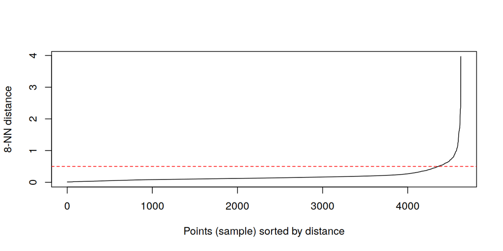

```r
kNNdistplot(Z, k = 8)                  # jarak ke tetangga ke-8 untuk setiap titik, diurutkan
abline(h = 0.5, lty = 2, col = "red")  # garis bantu di "siku" kurva -> kandidat eps
```

```r
db <- dbscan(Z, eps = 0.5, minPts = 8)   # eps = radius tetangga; minPts = min. titik agar disebut padat
db                                       # ringkasan: jumlah cluster dan noise (cluster 0 = noise)
```

```
#> DBSCAN clustering for 4624 objects.
#> Parameters: eps = 0.5, minPts = 8
#> Using euclidean distances and borderpoints = TRUE
#> The clustering contains 8 cluster(s) and 118 noise points.
#>
#>    0    1    2    3    4    5    6    7    8
#>  118 1279   62 1158  762 1096   51   74   24
#>
#> Available fields: cluster, eps, minPts, dist, borderPoints
```

- `eps` dipilih di sekitar “siku” `kNNdistplot` (garis merah).
- `minPts` ≈ 2 × jumlah variabel = 2 × 4 = 8.
- Di hasil DBSCAN, **cluster 0 = noise**.

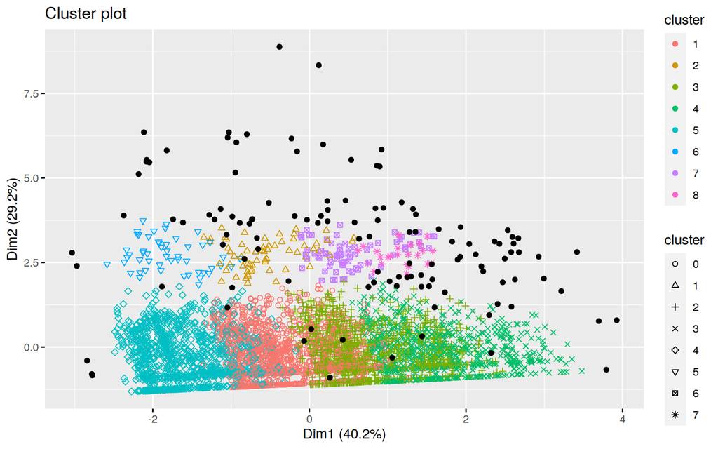

```r
fviz_cluster(db, data = Z, geom = "point", ellipse = FALSE, show.clust.cent = FALSE)
```

```r
noise <- db$cluster == 0   # TRUE jika polis ditandai noise
# bandingkan median polis noise dengan polis lain
rbind(noise = sapply(klaim[noise,  c("veh_value","veh_age","claimcst0","numclaims")], median),
      lain  = sapply(klaim[!noise, c("veh_value","veh_age","claimcst0","numclaims")], median))
```

```
#>       veh_value veh_age claimcst0 numclaims
#> noise      2.80       2   4250.30         2
#> lain       1.56       3    730.91         1
```

- DBSCAN menemukan 8 cluster dan **118 polis noise**. Banyaknya cluster kecil muncul karena `umur` dan `jumlah` hanya bernilai 1–4: DBSCAN memisahkan setiap kombinasi nilai diskrit yang padat. Jadi pada data ini DBSCAN **kurang cocok untuk segmentasi**.
- Namun sebagai **pendeteksi klaim tidak lazim** DBSCAN berguna: polis noise memiliki median biaya **4250 AUD** dibanding 731 AUD pada polis lain, median nilai kendaraannya lebih tinggi, dan median jumlah klaimnya 2 (klaim berulang). Polis seperti ini layak diperiksa lebih lanjut oleh tim klaim.
- Ganti `centers = 4` menjadi `3` pada k-means. Cluster mana yang bergabung? Mana yang lebih bermakna untuk bisnis?
- Coba `eps = 0.4` dan `eps = 0.8` pada DBSCAN. Bagaimana jumlah noise berubah?

# Part 4 · MCA pada Profil Polis

MCA adalah “PCA untuk data kategorik”. Di sini kita ingin melihat profil polis (jenis kendaraan, umur, nilai, pengemudi, wilayah) dan di mana posisi polis yang **mengajukan klaim**.

## Menyiapkan data

Untuk latihan kita ambil **sampel 2.000 polis** agar komputasi cepat (terutama untuk matriks jarak Gower di Part 5). Variabel numerik/ordinal dibuat menjadi kategori karena MCA hanya menerima data kategorik.

```r
set.seed(123)
P <- dataCar[sample(nrow(dataCar), 2000), ]   # ambil 2.000 baris secara acak

# 1) jenis bodi: 4 jenis terbanyak dipertahankan, sisanya digabung menjadi "LAIN"
P$bodi <- factor(ifelse(P$veh_body %in% c("SEDAN", "HBACK", "STNWG", "UTE"),
                        as.character(P$veh_body), "LAIN"))
# 2) umur kendaraan & usia pengemudi: angka 1-4 / 1-6 diubah menjadi kategori berlabel
P$umur_kend <- factor(P$veh_age, labels = c("baru", "2", "3", "tua"))
P$usia      <- factor(P$agecat,  labels = c("muda", "2", "3", "4", "5", "tua"))
# 3) nilai kendaraan: dibagi 4 kelompok sama besar berdasarkan kuartil
P$nilai <- cut(P$veh_value, breaks = quantile(P$veh_value, c(0, .25, .5, .75, 1)),
               include.lowest = TRUE, labels = c("murah", "sedang", "mahal", "sgt_mahal"))
# 4) status klaim sebagai kategori (nama dibuat jelas agar mudah dibaca di peta)
P$klaim <- factor(ifelse(P$clm == 1, "klaim_ya", "klaim_tidak"))
```

- `factor()` mengubah angka/teks menjadi **kategori**. `labels =` memberi nama pada setiap kategori sesuai urutannya.
- `ifelse(kondisi, jika_ya, jika_tidak)`: dipakai untuk menggabungkan jenis bodi yang jarang (BUS, COUPE, dll.) menjadi “LAIN”. Kategori yang sangat jarang akan terlalu dominan di MCA, jadi sebaiknya digabung.
- `cut()` memotong variabel numerik menjadi interval; `quantile(..., c(0,.25,.5,.75,1))` membuat 4 kelompok dengan jumlah anggota kira-kira sama.

```r
str(P[, c("bodi", "umur_kend", "nilai", "gender", "area", "usia", "klaim")])   # cek: semuanya Factor
```

```
#> 'data.frame':    2000 obs. of  7 variables:
#>  $ bodi     : Factor w/ 5 levels "HBACK","LAIN",..: 4 5 3 4 5 3 3 1 3 3 ...
#>  $ umur_kend: Factor w/ 4 levels "baru","2","3",..: 4 3 1 4 3 4 4 4 4 4 ...
#>  $ nilai    : Factor w/ 4 levels "murah","sedang",..: 3 1 3 2 3 1 1 1 2 1 ...
#>  $ gender   : Factor w/ 2 levels "F","M": 2 2 1 2 1 1 1 2 1 2 ...
#>  $ area     : Factor w/ 6 levels "A","B","C","D",..: 4 5 3 2 4 3 2 3 2 4 ...
#>  $ usia     : Factor w/ 6 levels "muda","2","3",..: 3 4 1 4 2 3 2 1 3 6 ...
#>  $ klaim    : Factor w/ 2 levels "klaim_tidak",..: 1 1 1 2 1 1 1 1 1 1 ...
```

## Menjalankan MCA

Variabel `klaim` dijadikan **variabel suplementer**: tidak ikut membentuk Dim, tetapi posisinya diproyeksikan ke peta sehingga bisa dibaca terhadap profil yang terbentuk.

```r
cat_vars <- c("bodi", "umur_kend", "nilai", "gender", "area", "usia", "klaim")   # urutan kolom
res.mca <- MCA(P[, cat_vars], quali.sup = 7, graph = FALSE)   # kolom ke-7 (klaim) = suplementer
round(head(res.mca$eig, 6), 2)                                # eigenvalue 6 Dim pertama
```

```
#>       eigenvalue percentage of variance cumulative percentage of variance
#> dim 1       0.30                   8.69                              8.69
#> dim 2       0.25                   7.02                             15.70
#> dim 3       0.21                   5.93                             21.63
#> dim 4       0.20                   5.64                             27.27
#> dim 5       0.19                   5.40                             32.67
#> dim 6       0.19                   5.35                             38.02
```

- `quali.sup = 7` = kolom ke-7 pada `cat_vars` (yaitu `klaim`) hanya “ikut ditampilkan”, tidak ikut dihitung.
- `graph = FALSE` = jangan langsung menggambar grafik bawaan; grafik kita buat sendiri dengan `fviz_mca_*`.

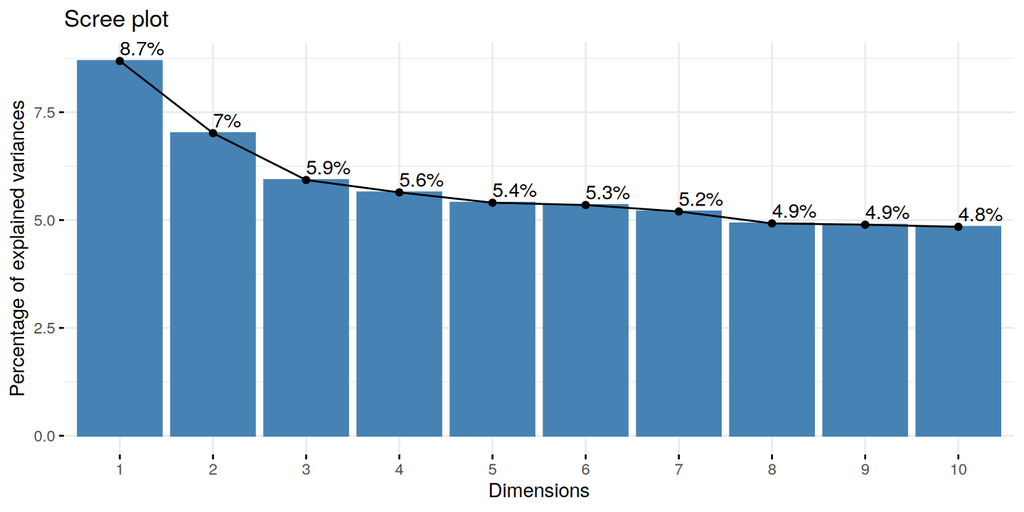

```r
fviz_eig(res.mca, addlabels = TRUE)   # scree plot MCA
```

- Persen varians per Dim pada MCA memang kecil (Dim 1 = 8.7%); ini wajar karena setiap kategori menjadi kolom 0/1 terpisah.
- Batas Kaiser untuk MCA adalah **1/Q**, dengan Q = jumlah variabel aktif = 6, yaitu 0.167. Ada 10 Dim yang melewati batas ini. Untuk visualisasi dan interpretasi kita fokus pada **Dim 1 dan Dim 2** yang paling besar dan jelas lebih tinggi daripada Dim berikutnya.

## Variabel mana yang membentuk tiap Dim?

```r
round(res.mca$var$eta2[, 1:2], 2)   # eta2: kekuatan hubungan tiap variabel dengan Dim 1 & 2 (0-1)
```

```
#>           Dim 1 Dim 2
#> bodi       0.45  0.29
#> umur_kend  0.29  0.55
#> nilai      0.82  0.39
#> gender     0.07  0.11
#> area       0.15  0.08
#> usia       0.04  0.05
```

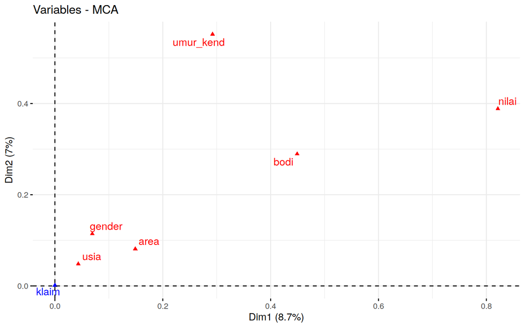

```r
fviz_mca_var(res.mca, choice = "mca.cor", repel = TRUE)   # peta variabel berdasarkan eta2
```

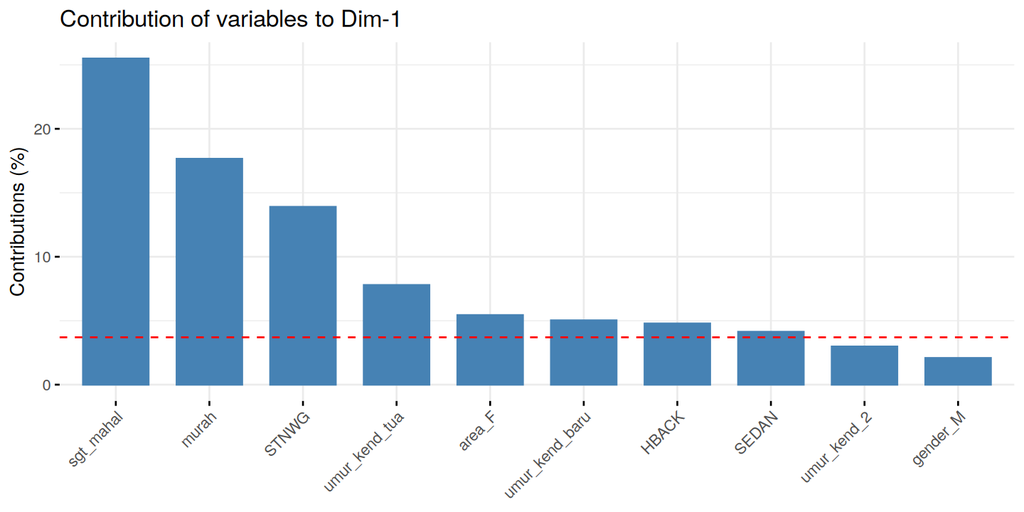

```r
fviz_contrib(res.mca, choice = "var", axes = 1, top = 10)   # 10 kategori penyumbang terbesar Dim 1
```

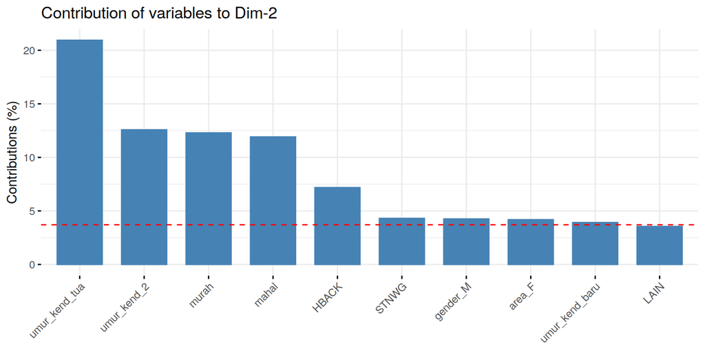

```r
fviz_contrib(res.mca, choice = "var", axes = 2, top = 10)   # 10 kategori penyumbang terbesar Dim 2
```

- **Dim 1** paling dipengaruhi **nilai kendaraan** (eta2 = 0.82) dan **jenis bodi**: sumbu **murah ↔︎ mahal**.
- **Dim 2** paling dipengaruhi **umur kendaraan** (eta2 = 0.55), lalu nilai dan bodi: sumbu **baru ↔︎ tua**.
- Gender, wilayah, dan usia pengemudi hanya berperan kecil di dua Dim ini.
- Garis merah putus-putus pada plot kontribusi = kontribusi rata-rata yang diharapkan; kategori di atas garis adalah pembentuk utama Dim tersebut.

## Peta kategori dan cara membacanya per kuadran

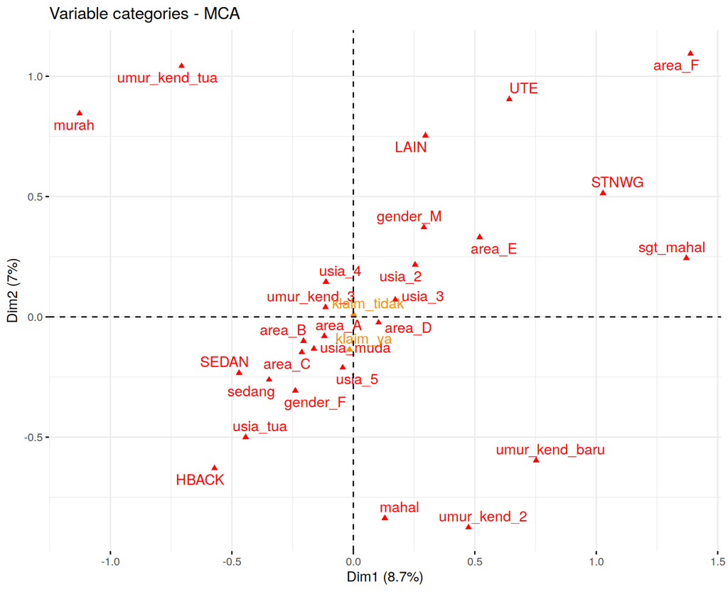

```r
fviz_mca_var(res.mca, repel = TRUE,            # peta semua kategori
             col.quali.sup = "darkorange")     # kategori suplementer (klaim) diberi warna oranye
```

**Cara membaca:**

- **Titik pusat (0, 0) = profil rata-rata.** Kategori yang dekat pusat (misalnya `area_A`, `usia_3`) adalah kategori umum yang tidak khas. Makin jauh dari pusat, makin khas.
- **Kiri ↔︎ kanan (Dim 1)**: kiri berisi `murah`, `HBACK` (hatchback), `SEDAN`; kanan berisi `sgt_mahal`, `STNWG` (station wagon), `UTE` (pikap), dan `umur_kend_baru`. Jadi Dim 1 = kendaraan kecil/murah ↔︎ kendaraan besar/mahal.
- **Atas ↔︎ bawah (Dim 2)**: atas berisi `umur_kend_tua`, `murah`, `UTE`, `LAIN`; bawah berisi `umur_kend_2`, `umur_kend_baru`, `mahal`, `HBACK`. Jadi Dim 2 = kendaraan baru ↔︎ tua.
- Kategori dalam **kuadran yang sama** cenderung muncul bersama:
  - **kiri-atas** = kendaraan murah dan tua;
  - **kanan-atas** = station wagon/pikap bernilai sangat tinggi, termasuk wilayah `area_F` (kategori jarang, sehingga letaknya jauh);
  - **kanan-bawah** = kendaraan baru dan mahal;
  - **kiri-bawah** = hatchback dan sedan.
- **Variabel suplementer (oranye)**: `klaim_ya` dan `klaim_tidak` **hampir berada di pusat** (eta2 dengan Dim 1–2 ≈ 0.001). Artinya, peluang klaim **hampir tidak berbeda** antar profil kendaraan ini. Ini temuan penting: risiko klaim tidak bisa dibaca hanya dari profil kendaraan; perlu model prediksi (misalnya regresi logistik/GLM frekuensi) yang juga memperhitungkan `exposure`.

Kategori dari variabel yang sama selalu berada di sisi berlawanan terhadap pusat (misalnya `gender_F` vs `gender_M`), dan kategori yang lebih jarang terletak lebih jauh. Jangan menilai jarak antar dua kategori dari variabel berbeda secara terlalu harfiah; cek juga cos2.

## Individu diwarnai status klaim

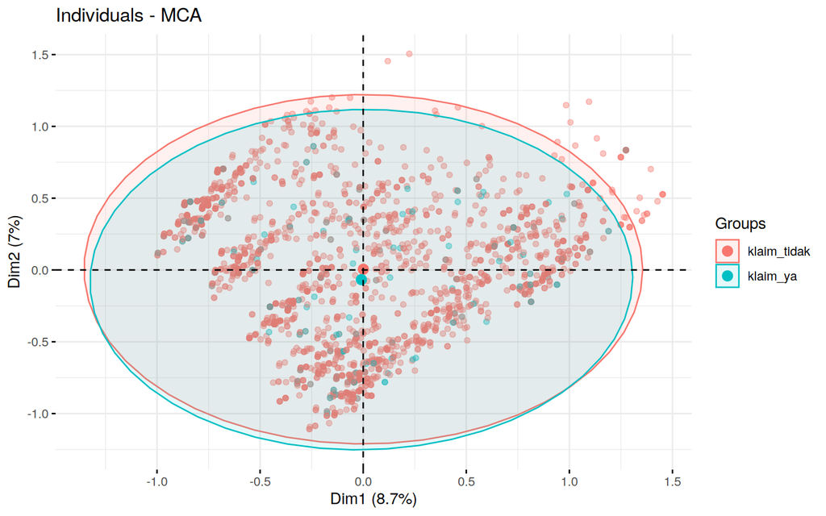

```r
fviz_mca_ind(res.mca, habillage = P$klaim,     # warnai titik berdasarkan status klaim
             geom = "point", addEllipses = TRUE, # tambahkan elips kelompok
             alpha.ind = 0.4)
```

Elips kedua kelompok **hampir menumpuk sempurna**: polis yang klaim tersebar di semua profil. Ini wajar karena `klaim` tidak ikut membentuk Dim, dan konsisten dengan posisi `klaim_ya` yang dekat pusat.

Jalankan ulang MCA dengan `klaim` sebagai variabel aktif (hapus argumen `quali.sup`). Apakah Dim 1 dan Dim 2 berubah? Kategori apa yang sekarang berdekatan dengan `klaim_ya`?

# Part 5 · Clustering Data Campuran (Profil Nasabah)

Data polis berisi variabel **numerik** (`veh_value`, `exposure`, `veh_age`, `agecat`) dan **kategorik** (`bodi`, `gender`, `area`). Jarak Euclid tidak cocok, jadi kita pakai **jarak Gower**. Status klaim **tidak dipakai** untuk membentuk cluster, tetapi dipakai untuk menafsirkan hasilnya.

## Jarak Gower + PAM

```r
# pilih variabel pembentuk cluster (tanpa variabel klaim)
M <- P[, c("veh_value", "exposure", "veh_age", "agecat", "bodi", "gender", "area")]
g <- daisy(M, metric = "gower")   # matriks jarak Gower: bisa untuk numerik + kategorik sekaligus
```

- `daisy(..., metric = "gower")` otomatis mengenali kolom numerik (dihitung selisih relatif) dan kolom factor (cocok = 0, beda = 1).
- Pastikan variabel kategorik sudah berbentuk **factor**; jika masih teks/angka, Gower akan menganggapnya numerik.

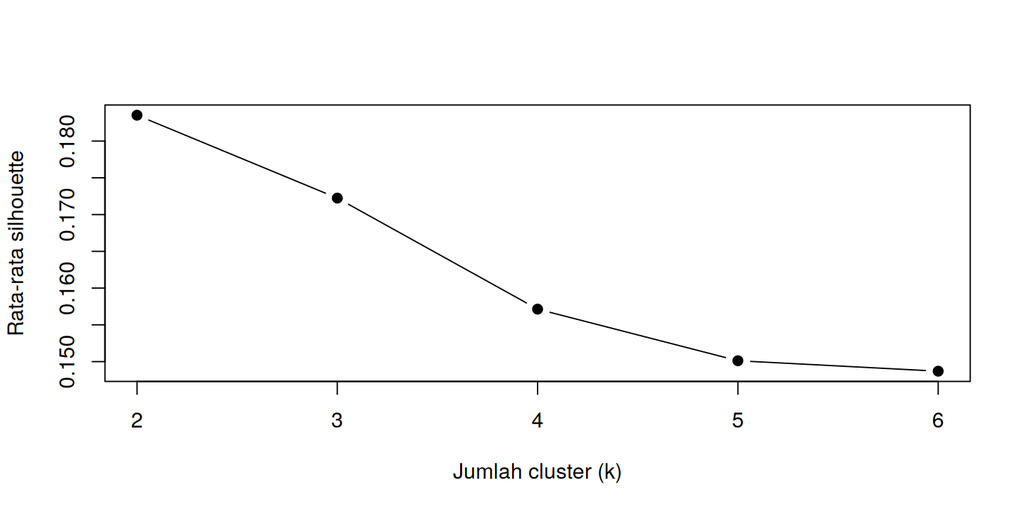

```r
# hitung rata-rata silhouette PAM untuk k = 2 sampai 6
sil <- sapply(2:6, function(k) pam(g, k, diss = TRUE)$silinfo$avg.width)
plot(2:6, sil, type = "b", pch = 19,                   # plot garis + titik
     xlab = "Jumlah cluster (k)", ylab = "Rata-rata silhouette")
```

- `sapply(2:6, function(k) ...)` = “ulangi perintah untuk k = 2, 3, 4, 5, 6 lalu kumpulkan hasilnya”. Ini cara singkat pengganti *for-loop*.
- `diss = TRUE` memberi tahu `pam()` bahwa input `g` sudah berupa **matriks jarak**, bukan data mentah.

```r
k_pilih <- 4                              # jumlah cluster yang dipilih (lihat interpretasi di bawah)
pg <- pam(g, k = k_pilih, diss = TRUE)    # PAM pada matriks jarak Gower
table(pg$clustering)                      # jumlah polis per cluster
```

```
#>
#>   1   2   3   4
#> 450 444 562 544
```

Silhouette tertinggi ada di k = 2 (0.18), tetapi nilai untuk k = 4 (0.16) tidak jauh berbeda. Dengan k = 2 data hanya terbelah menurut gender, sehingga kurang informatif. Kita pilih **k = 4** agar segmen juga dibedakan oleh jenis kendaraan dan wilayah.

## Profil cluster

```r
P$cluster <- factor(pg$clustering)                                    # simpan nomor cluster ke data
num <- aggregate(cbind(veh_value, veh_age, agecat) ~ cluster, data = P, FUN = mean)  # rata-rata numerik
pct <- function(v, lv) round(100 * tapply(P[[v]] == lv, P$cluster, mean))  # fungsi bantu: % kategori lv
top <- function(v) tapply(P[[v]], P$cluster, function(x) names(which.max(table(x))))  # kategori terbanyak
profil <- data.frame(num,
  n            = as.vector(table(P$cluster)),
  pria_pct     = pct("gender", "M"),
  bodi_utama   = top("bodi"),
  area_utama   = top("area"),
  KLAIM_pct    = round(100 * tapply(P$clm, P$cluster, mean), 1))   # % polis yang klaim
knitr::kable(profil, digits = 2, caption = "Profil tiap cluster nasabah")
```

Profil tiap cluster nasabah

| cluster | veh_value | veh_age | agecat | n | pria_pct | bodi_utama | area_utama | KLAIM_pct |
| --- | --- | --- | --- | --- | --- | --- | --- | --- |
| 1 | 2.27 | 2.94 | 3.08 | 450 | 83 | STNWG | B | 6.0 |
| 2 | 1.59 | 2.80 | 3.97 | 444 | 100 | SEDAN | C | 5.2 |
| 3 | 1.45 | 2.98 | 3.50 | 562 | 0 | SEDAN | C | 8.0 |
| 4 | 1.82 | 2.20 | 3.47 | 544 | 15 | HBACK | A | 8.5 |

- `pct("gender", "M")` = persentase pengemudi pria di setiap cluster. Fungsi kecil `pct()` dibuat supaya tidak menulis rumus yang sama berulang kali.
- `top("bodi")` = jenis bodi yang paling sering muncul di setiap cluster (modus).
- `KLAIM_pct` = persentase polis yang klaim; **bukan** bagian pembentuk cluster, hanya untuk menafsirkan.

Cluster terbentuk terutama oleh **gender** dan **jenis bodi** (variabel kategorik mendapat bobot besar dalam Gower):

- **Cluster 1** (450 polis): 83% pria, bodi utama STNWG, wilayah utama B, rata-rata nilai kendaraan 2.27, **6% klaim**.
- **Cluster 2** (444 polis): 100% pria, bodi utama SEDAN, wilayah utama C, rata-rata nilai kendaraan 1.59, **5.2% klaim**.
- **Cluster 3** (562 polis): 0% pria, bodi utama SEDAN, wilayah utama C, rata-rata nilai kendaraan 1.45, **8% klaim**.
- **Cluster 4** (544 polis): 15% pria, bodi utama HBACK, wilayah utama A, rata-rata nilai kendaraan 1.82, **8.5% klaim**.

Usulan nama segmen: **1 = pria, station wagon mahal**; **2 = pria, sedan, pengemudi lebih tua**; **3 = wanita, sedan**; **4 = wanita, hatchback lebih baru**.

Tingkat klaim tertinggi ada di **cluster 4** (8.5%) dan terendah di **cluster 2** (5.2%). Selisih ini cukup berarti secara bisnis (rata-rata seluruh sampel 7%), sehingga bisa menjadi masukan untuk diferensiasi premi atau fokus pemasaran. Karena sampel hanya 2.000 polis, selisihnya perlu dikonfirmasi pada data penuh atau dengan model GLM.

## Visualisasi cluster di peta MCA

`fviz_cluster` butuh data numerik, jadi cluster Gower kita tampilkan di atas **koordinat individu MCA** dari Part 4.

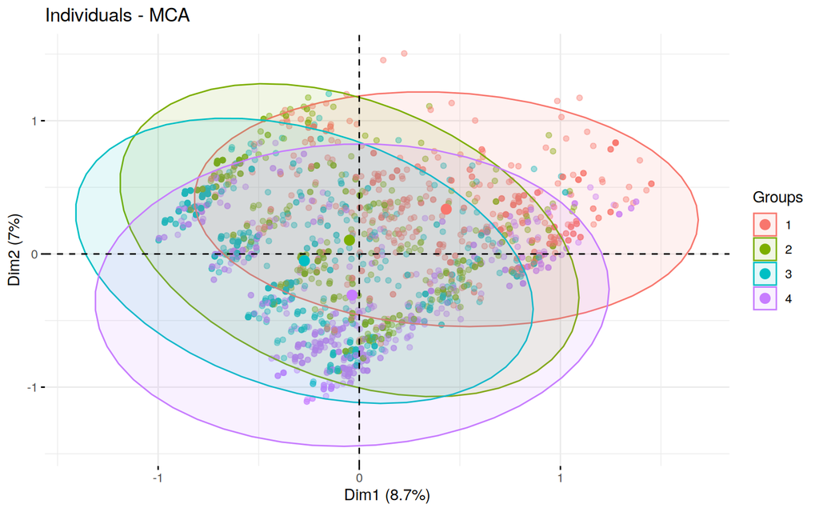

```r
fviz_mca_ind(res.mca, habillage = P$cluster,   # titik = polis, warna = cluster Gower
             geom = "point", addEllipses = TRUE, alpha.ind = 0.4)
```

## Hierarchical clustering dengan jarak Gower

```r
hc_g <- hclust(g, method = "ward.D2")   # hierarchical langsung dari matriks jarak Gower
```

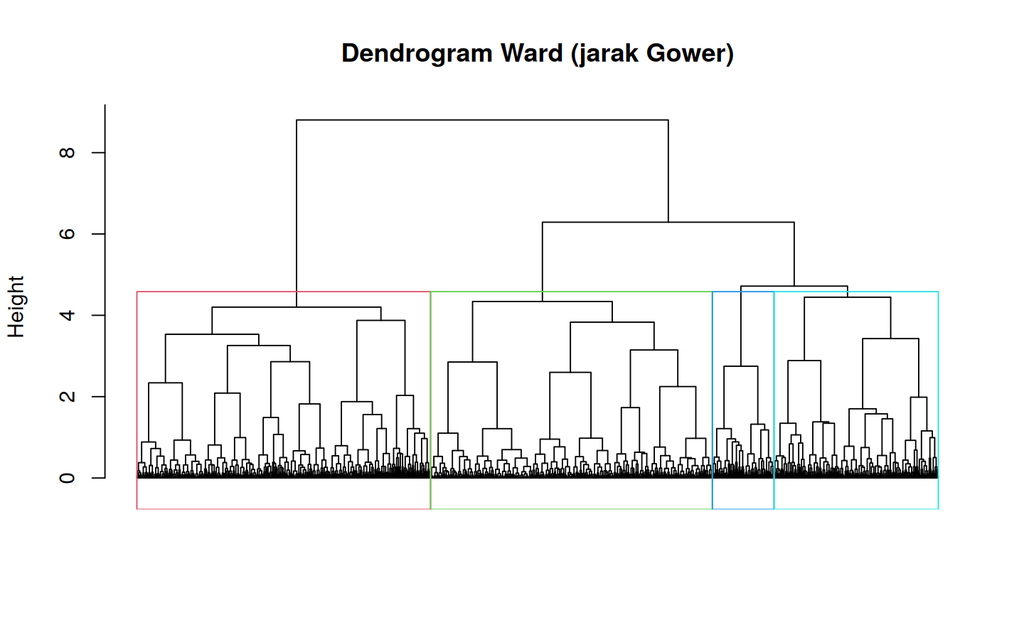

```r
plot(hc_g, labels = FALSE, hang = -1, main = "Dendrogram Ward (jarak Gower)", xlab = "", sub = "")
rect.hclust(hc_g, k = k_pilih, border = 2:5)
```

```r
table(Hierarki = cutree(hc_g, k = k_pilih), PAM = pg$clustering)   # bandingkan dengan PAM
```

```
#>         PAM
#> Hierarki   1   2   3   4
#>        1 260 371  20  82
#>        2 159  33 101 117
#>        3   0   0 390 313
#>        4  31  40  51  32
```

Tabel silang menunjukkan apakah hierarchical clustering menemukan segmen yang sama dengan PAM. Jika sebagian besar anggota berkumpul di satu sel per baris, kedua metode sepakat dan segmen tersebut cukup stabil. Di sini kesepakatannya hanya sebagian: hierarchical juga memisahkan pria dan wanita (baris 3 hanya berisi cluster PAM 3 dan 4 yang mayoritas wanita), tetapi tidak memisahkan jenis kendaraan sejelas PAM. Artinya pembagian menurut **gender** stabil, sedangkan pembagian menurut **jenis kendaraan** lebih bergantung pada metode.

## Opsional: K-Prototypes dan K-Modes

Chunk di bawah hanya dijalankan jika package `clustMixType` / `klaR` sudah terpasang.

```r
library(clustMixType)
set.seed(123)
kp <- kproto(M, k = k_pilih, verbose = FALSE)             # k-prototypes: untuk data campuran
table(KProto = kp$cluster, PAM = pg$clustering)            # bandingkan dengan PAM
round(100 * tapply(P$clm, kp$cluster, mean), 1)            # % klaim per cluster
```

```r
library(klaR)
set.seed(123)
C <- P[, c("bodi", "umur_kend", "nilai", "gender", "area", "usia")]   # hanya variabel kategorik
kmo <- kmodes(C, modes = k_pilih)                                     # k-modes: untuk data kategorik
kmo$modes                                                             # kategori khas tiap cluster
round(100 * tapply(P$clm, kmo$cluster, mean), 1)                      # % klaim per cluster
```

K-Prototypes menggabungkan jarak Euclid (numerik) dan jumlah ketidakcocokan (kategorik) dengan bobot `lambda`; K-Modes hanya untuk data kategorik dan memakai **modus** sebagai pusat cluster. Keduanya perlu `set.seed()` karena hasil bergantung pada titik awal.

- Keluarkan `gender` dari data `M`, lalu ulangi Gower + PAM. Variabel apa yang sekarang membedakan cluster?
- Hitung rata-rata biaya klaim (`claimcst0`) hanya untuk polis yang klaim di setiap cluster. Segmen mana yang paling mahal dari sisi keparahan klaim?

# Part 6 · Ringkasan

| Metode | Jenis data | Fungsi R | Kapan dipakai |
| --- | --- | --- | --- |
| PCA | Numerik | `prcomp()` | Meringkas variabel numerik berkorelasi; visualisasi 2D |
| MCA | Kategorik | `FactoMineR::MCA()` | Memetakan hubungan antar kategori / profil nasabah |
| K-Means | Numerik | `kmeans()` | Segmentasi cepat, cluster bulat, perlu tentukan k |
| K-Medoids (PAM) | Numerik / matriks jarak | `cluster::pam()` | Lebih tahan outlier; bisa dipakai dengan jarak Gower |
| Hierarchical | Matriks jarak | `hclust()` | Melihat struktur bertingkat lewat dendrogram |
| DBSCAN | Numerik | `dbscan::dbscan()` | Tidak perlu k, mendeteksi noise / klaim tidak lazim |
| Gower + PAM | Campuran | `daisy()` + `pam()` | Data campuran numerik & kategorik |
| K-Prototypes | Campuran | `clustMixType::kproto()` | Alternatif untuk data campuran |
| K-Modes | Kategorik | `klaR::kmodes()` | Data kategorik murni |

**Pesan utama:**

- Transformasi dan standardisasi data (log, `scale`) sangat menentukan hasil PCA dan clustering pada data klaim yang miring.
- Tentukan k dengan kombinasi ukuran statistik (elbow, silhouette) **dan** kebutuhan interpretasi bisnis.
- Profil cluster selalu dibaca dari **data asli**, lalu diberi nama segmen yang bermakna.
- Variabel diskrit (nilai 1–4) membuat pola “bergaris” dan bisa mengacaukan metode berbasis kepadatan seperti DBSCAN.
- Clustering adalah alat **segmentasi/profiling**, bukan prediksi. Untuk memprediksi (misalnya siapa yang akan klaim), lanjutkan dengan model seperti regresi logistik atau GLM frekuensi-keparahan.

# Part 7 · Contekan Kode Wajib

Semua kode berlabel **WAJIB** dirangkum di sini sebagai **pola** yang bisa dipakai ulang pada data lain. Hafalkan pola ini; kode grafik (PELENGKAP) cukup dilihat saat dibutuhkan.

```r
## 0. PERSIAPAN --------------------------------------------------------------
library(cluster); library(factoextra); library(FactoMineR); library(dbscan)
data("dataCar", package = "insuranceData")

## 1. SIAPKAN DATA NUMERIK ----------------------------------------------------
klaim <- subset(dataCar, clm == 1)                   # pilih baris
X <- data.frame(nilai = log1p(klaim$veh_value),      # log untuk data miring
                umur  = klaim$veh_age,
                biaya = log(klaim$claimcst0),
                jumlah = klaim$numclaims)
Z <- scale(X)                                        # standardisasi
cor(X)                                               # cek korelasi

## 2. PCA ---------------------------------------------------------------------
res.pca <- prcomp(X, scale. = TRUE)
get_eigenvalue(res.pca)                              # berapa Dim dipakai?
res.pca$rotation                                     # loading -> arti tiap Dim

## 3. CLUSTERING NUMERIK ------------------------------------------------------
fviz_nbclust(Z, kmeans, method = "silhouette")       # pilih k
set.seed(123); km <- kmeans(Z, centers = 4, nstart = 25)   # k-means
pm <- pam(Z, k = 4)                                  # k-medoids
hc <- hclust(dist(Z), method = "ward.D2"); cutree(hc, k = 4)   # hierarchical
db <- dbscan(Z, eps = 0.5, minPts = 8)               # DBSCAN (cluster 0 = noise)
aggregate(klaim[, c("veh_value", "claimcst0")],      # PROFIL dari data asli
          by = list(cluster = km$cluster), FUN = median)

## 4. MCA ---------------------------------------------------------------------
# semua variabel harus factor; variabel yang ingin "ditumpangkan" -> quali.sup
res.mca <- MCA(P[, cat_vars], quali.sup = 7, graph = FALSE)
res.mca$eig                                          # eigenvalue
res.mca$var$eta2                                     # variabel pembentuk Dim

## 5. DATA CAMPURAN: GOWER + PAM ----------------------------------------------
g  <- daisy(M, metric = "gower")                     # jarak untuk numerik + kategorik
sil <- sapply(2:6, function(k) pam(g, k, diss = TRUE)$silinfo$avg.width)   # pilih k
pg <- pam(g, k = 4, diss = TRUE)                     # cluster
hc_g <- hclust(g, method = "ward.D2")                # pembanding
```

**Pola yang selalu sama di setiap metode:** (1) siapkan data → (2) tentukan k (jika perlu) → (3) jalankan fungsi metode dan simpan ke objek → (4) ambil nomor cluster (`$cluster`, `$clustering`, atau `cutree()`) → (5) buat **profil dari data asli** dengan `aggregate()` / `tapply()` → (6) beri nama segmen.

```
#> Dibuat dengan R version 4.3.3 (2024-02-29)
```